# Data Analysis Demonstration

Jiaying Wu

Mar 19, 2021

## Load Data

```r
# load data
data(NHANES)
head(NHANES)
```

```
## # A tibble: 6 x 76
##      ID SurveyYr Gender   Age AgeDecade AgeMonths Race1 Race3 Education
##   <int> <fct>    <fct>  <int> <fct>         <int> <fct> <fct> <fct>
## 1 51624 2009_10  male      34 " 30-39"        409 White <NA>  High Sch…
## 2 51624 2009_10  male      34 " 30-39"        409 White <NA>  High Sch…
## 3 51624 2009_10  male      34 " 30-39"        409 White <NA>  High Sch…
## 4 51625 2009_10  male       4 " 0-9"           49 Other <NA>  <NA>
## 5 51630 2009_10  female    49 " 40-49"        596 White <NA>  Some Col…
## 6 51638 2009_10  male       9 " 0-9"          115 White <NA>  <NA>
## # … with 67 more variables: MaritalStatus <fct>, HHIncome <fct>,
## #   HHIncomeMid <int>, Poverty <dbl>, HomeRooms <int>, HomeOwn <fct>,
## #   Work <fct>, Weight <dbl>, Length <dbl>, HeadCirc <dbl>, Height <dbl>,
## #   BMI <dbl>, BMICatUnder20yrs <fct>, BMI_WHO <fct>, Pulse <int>,
## #   BPSysAve <int>, BPDiaAve <int>, BPSys1 <int>, BPDia1 <int>, BPSys2 <int>,
## #   BPDia2 <int>, BPSys3 <int>, BPDia3 <int>, Testosterone <dbl>,
## #   DirectChol <dbl>, TotChol <dbl>, UrineVol1 <int>, UrineFlow1 <dbl>,
## #   UrineVol2 <int>, UrineFlow2 <dbl>, Diabetes <fct>, DiabetesAge <int>,
## #   HealthGen <fct>, DaysPhysHlthBad <int>, DaysMentHlthBad <int>,
## #   LittleInterest <fct>, Depressed <fct>, nPregnancies <int>, nBabies <int>,
## #   Age1stBaby <int>, SleepHrsNight <int>, SleepTrouble <fct>,
## #   PhysActive <fct>, PhysActiveDays <int>, TVHrsDay <fct>, CompHrsDay <fct>,
## #   TVHrsDayChild <int>, CompHrsDayChild <int>, Alcohol12PlusYr <fct>,
## #   AlcoholDay <int>, AlcoholYear <int>, SmokeNow <fct>, Smoke100 <fct>,
## #   Smoke100n <fct>, SmokeAge <int>, Marijuana <fct>, AgeFirstMarij <int>,
## #   RegularMarij <fct>, AgeRegMarij <int>, HardDrugs <fct>, SexEver <fct>,
## #   SexAge <int>, SexNumPartnLife <int>, SexNumPartYear <int>, SameSex <fct>,
## #   SexOrientation <fct>, PregnantNow <fct>
```

```r
# create variables, do filtering, etc.
adult_linear <- NHANES %>%
  filter(Age >= 18) %>%
  filter(AgeFirstMarij <= 30) %>%
  filter(SmokeAge >= 18) %>%
  filter(!is.na(SmokeAge)) %>%
  filter(!is.na(AgeFirstMarij)) %>%
  filter(!is.na(Education))

# create regular linear regression
mod1 <-
  adult_linear %>%
  with(lm(AgeFirstMarij ~ SmokeAge + Education))

tidy(mod1)
```

```
## # A tibble: 6 x 5
##   term                    estimate std.error statistic  p.value
##   <chr>                      <dbl>     <dbl>     <dbl>    <dbl>
## 1 (Intercept)               9.32      1.48        6.29 5.93e-10
## 2 SmokeAge                  0.0785    0.0244      3.21 1.39e- 3
## 3 Education9 - 11th Grade   7.13      1.45        4.90 1.24e- 6
## 4 EducationHigh School      6.51      1.43        4.53 7.00e- 6
## 5 EducationSome College     6.52      1.43        4.58 5.77e- 6
## 6 EducationCollege Grad     7.01      1.43        4.90 1.21e- 6
```

## Bootstrapping for Linear Regression Model

```r
# set to be the same each time
set.seed(1)

# 500 bootstrap samples
boot_data_linear <- mosaic::do(500)*(
  adult_linear %>%
  sample_frac(replace = TRUE) %>%
  with(lm(AgeFirstMarij ~ SmokeAge + Education))
)

# look at bootstrap estimates (and variable names)
head(boot_data_linear)
```

```
##   Intercept   SmokeAge Education9...11th.Grade EducationHigh.School
## 1  9.126737 0.08324426                7.063695             6.382954
## 2 11.575163 0.07915760                5.287914             4.170443
## 3  8.149280 0.10281779                7.705881             7.105632
## 4  8.405883 0.08856207                7.510478             7.228804
## 5  9.778194 0.06640251                6.330289             6.123808
## 6  8.404702 0.08862765                7.011238             7.082364
##   EducationSome.College EducationCollege.Grad    sigma  r.squared         F
## 1              6.435532              7.582709 3.125680 0.09942911 13.315055
## 2              4.556453              4.505374 3.138720 0.04122688  5.185755
## 3              7.307110              7.624862 3.196988 0.06335322  8.157183
## 4              7.272075              8.292319 3.093748 0.08208222 10.784316
## 5              6.693068              7.281580 3.134052 0.09670069 12.910563
## 6              7.303209              7.665863 3.112143 0.08519865 11.231899
##   numdf dendf .row .index
## 1     5   603    1      1
## 2     5   603    1      2
## 3     5   603    1      3
## 4     5   603    1      4
## 5     5   603    1      5
## 6     5   603    1      6
```

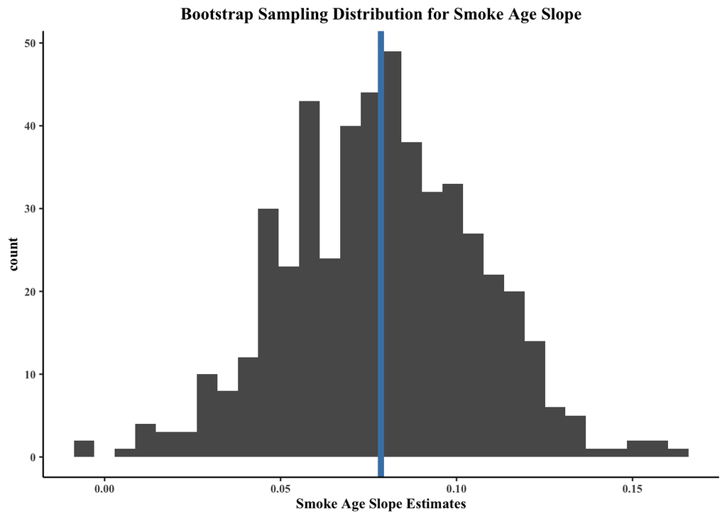

```r
# visualize the bootstrap sampling distribution for one slope coefficient of interest
boot_data_linear %>%
  ggplot(aes(x = SmokeAge)) +
  geom_histogram() +
  labs(x = "Smoke Age Slope Estimates", title = "Bootstrap Sampling Distribution for Smoke Age Slope") +
  theme_classic() +
  theme(plot.title = element_text(hjust = 0.5)) +
  theme(text = element_text(family = "Times New Roman", face = "bold", size = 10)) +
  geom_vline(xintercept = coef(mod1)[2], lwd = 2, color = "steelblue")
```

> Description of the bootstrap sampling distribution (center, spread, shape): The bootstrap Sampling Distribution describes 500 random samples in the bootstrap sampling of the smoke age coefficient. The normal is roughly symmetrical and unimodal, centered at 0.08 years of age, which is shorter than one month. This centered 0.08 year is the average estimated difference in the marijuana start smoking age if someone starts to smoke cigarettes one year later, taking into account their educational levels are the same.

> Description of what information the bootstrap sampling distribution provides: Based on where the original sample estimates (blue vertical lines) is, it seems that our bootstrapping sample’s distribution is very near to the original smoke age slope coefficient. This tells us that if we use the 68-95-99.7 rule (2 SE’s) for our classical approach, we’ll come to roughly the same conclusion as if we did bootstrap CI’s. That being said, bootstrapping provides us a reliable approach to get that there is on average an estimated 0.08 year difference in the marijuana start smoking age compared to someone starts to smoke cigarettes one year later, taking into account their educational levels are the same. The coefficient estimates are slightly spread out, suggesting that there is variability in our estimates. However, considering the unit of smoking age, the whole 95% CI is only roughly one month. We should not concern too much about the variation shown in the visualization. Lastly, it is important to notice that there is a rare chance that smoke age slope estimates could go below 0, which means that it is possible that start smoking cigarettes age does not affect the age of smoking marijuana, even after accounting for educational backgrounds.